# Absorption-Only Forward Model Comparison

This notebook compares the **legacy** `ForwardFunction` from `retrieval.py` to the **new** pipeline built from:

| New module | Role |
| --- | --- |
| `python/atmosphere.py` | `AtmosphericProfile` — typed state vector |
| `python/absco.py` | `ABSCOTable` — bilinear p-T lookup, replaces `sigma_lookup()` |
| `python/surface.py` | `LambertianSurface` — albedo / π BRDF |
| `python/instrument.py` | `SpectralWindow` + `ILS` — Gaussian ILS convolution |

**Scenario**: absorption-only (no aerosols), Lambertian surface, OCO-2-like geometry.

```python
import numpy as np
import matplotlib.pyplot as plt
import matplotlib.gridspec as gridspec
import sys, os

# Make sure the repo root is on the path
repo_root = os.path.abspath('.')
if repo_root not in sys.path:
    sys.path.insert(0, repo_root)

# ── Legacy imports ────────────────────────────────────────────────────────────
import settings as s
from absco_lookup import load_absco_file
from retrieval import ForwardFunction, planck, layer_average

# ── New-pipeline imports ──────────────────────────────────────────────────────
from python.atmosphere import AtmosphericProfile
from python.absco      import ABSCOTable
from python.surface    import LambertianSurface
from python.instrument import ILS, SpectralWindow

print('All imports OK')
```

```
All imports OK
```

## 1 Load ABSCO tables

Both pipelines read from the same `absco.h5` file.  
The legacy code uses `load_absco_file()` which returns a flat dict.  
The new code wraps each molecule in an `ABSCOTable` dataclass.

```python
ABSCO_H5 = s.ABSCO_TABLE_FILE          # './absco.h5' from site_settings.yml

# Legacy flat dict
absco_data = load_absco_file(ABSCO_H5)

# New typed tables
absco_tables = ABSCOTable.load_all(ABSCO_H5)

print('Legacy keys (first 4):', list(absco_data.keys())[:4])
for mol, tbl in absco_tables.items():
    print(' ', tbl)
```

```
Legacy keys (first 4): ['absco_h2o_dataset', 'absco_h2o_wavenumber', 'absco_h2o_p', 'absco_h2o_T']
  ABSCOTable(molecule='h2o', wn=4219.00–13513.00 cm⁻¹, grid=64p×17T×128704wn)
  ABSCOTable(molecule='co2', wn=4760.00–6300.00 cm⁻¹, grid=64p×17T×35002wn)
  ABSCOTable(molecule='o2', wn=12745.00–13245.00 cm⁻¹, grid=64p×17T×50001wn)
  ABSCOTable(molecule='ch4', wn=4219.00–6285.00 cm⁻¹, grid=64p×17T×59403wn)
```

## 2 Build the old (legacy) forward model

`ForwardFunction` with `tau_aerosol=None` gives the absorption-only scenario. We disable `measurement_error` so both paths return deterministic radiances.

```python
old = ForwardFunction(
    absco_data=absco_data,
    tau_aerosol=None,
    measurement_error=False,
    jacobians=False,
)

print(f'Old model computed {len(old.y)} measurement channels')
print(f'Band channel counts: {[len(r) for r in old.R_band]}')
```

```
Old model computed 3874 measurement channels
Band channel counts: [1003, 1212, 1659]
```

## 3 Build the new pipeline

### 3a AtmosphericProfile

We pass the same `p_true`, `T_true`, `q_true`, `co2_true`, `ch4_true` arrays from `settings.py` into the typed `AtmosphericProfile`.

```python
atm = AtmosphericProfile(
    p_levels = s.p_true,
    T_levels = s.T_true,
    q_levels = s.q_true,
    gases    = {'co2': s.co2_true, 'ch4': s.ch4_true},
)

# Verify that layer quantities match the legacy ForwardFunction
assert np.allclose(atm.p_layers, old.p_layer), 'p_layers mismatch'
assert np.allclose(atm.T_layers, old.T_layer), 'T_layers mismatch'
assert np.allclose(atm.q_layers, old.q_layer), 'q_layers mismatch'
assert np.allclose(atm.gas_layers['co2'], old.co2_layer), 'co2_layers mismatch'
assert np.allclose(atm.gas_layers['ch4'], old.ch4_layer), 'ch4_layers mismatch'
print('✓  All layer quantities match between old and new')

print(f'\nXCO₂  old = {old.xco2:.4f} ppm    new = {atm.column_xgas("co2")*1e6:.4f} ppm')
print(f'XCH₄  old = {old.xch4:.4f} ppb    new = {atm.column_xgas("ch4")*1e9:.4f} ppb')
```

```
✓  All layer quantities match between old and new

XCO₂  old = 415.7753 ppm    new = 415.7753 ppm
XCH₄  old = 1789.7036 ppb    new = 1789.7036 ppb
```

### 3b SpectralWindows + LambertianSurface

```python
band_labels    = ['O₂ A-band', 'Weak CO₂', 'CH₄']
band_molecules = [['o2', 'h2o'], ['co2', 'h2o'], ['ch4', 'h2o']]

windows = []
for i in range(3):
    wn_centre = 0.5 * (s.band_min_wn[i] + s.band_max_wn[i])
    ils = ILS.from_fwhm_nm(
        fwhm_nm   = s.band_spectral_resolutions[i],
        wn_centre = wn_centre,
    )
    win = SpectralWindow(
        wn_min    = s.band_min_wn[i],
        wn_max    = s.band_max_wn[i],
        ils       = ils,
        molecules = band_molecules[i],
        label     = band_labels[i],
        fwhm_nm   = s.band_spectral_resolutions[i],
    )
    windows.append(win)
    print(f'Band {i}: {win.label:12s}  '
          f'hires={len(win.wn_hires):6d} pts  '
          f'instrument={win.n_channels:4d} channels  '
          f'σ_ILS={win.ils.sigma:.4f} cm⁻¹')

# Lambertian surface (per-band albedo, no slope)
surface = LambertianSurface(albedo=s.albedo_true)
```

```
Band 0: O₂ A-band     hires= 24001 pts  instrument=1003 channels  σ_ILS=0.3047 cm⁻¹
Band 1: Weak CO₂      hires= 11901 pts  instrument=1212 channels  σ_ILS=0.1251 cm⁻¹
Band 2: CH₄           hires= 15501 pts  instrument=1659 channels  σ_ILS=0.1190 cm⁻¹
```

## 4 New forward model: compute radiances band by band

The absorption-only intensity formula (matches `ForwardFunction.intensity` with `tau_aerosol=0`):

$$I(\nu) = \frac{F_\odot}{\pi} \cdot A \cdot \mu_0 \cdot \exp\!\left[-m \, \tau^*(\nu)\right]$$

where

- $F_\odot$ = Planck at 5800 K × solar solid angle (per band)
- $m = 1/\mu_0 + 1/\mu$ = airmass factor
- $\tau^* = \sum_\text{mol} \tau_\text{mol}(\nu) + \tau_\text{Rayleigh}$ (column-summed)

**Rayleigh optical depth** uses the single mean band wavelength (same approximation as the legacy code).

```python
# ── Physical constants (match retrieval.py) ───────────────────────────────────
_g  = 9.81
_M  = 0.0289644
_Na = 6.022e23
_sigma_sun = 6.794e-5        # sr  (solid angle of the Sun)
_h  = 6.62607015e-34
_c  = 2.99792458e8
_k  = 1.381e-23
_a_rayleigh  = 2.871e-4
_b_rayleigh  = 5.67e-3
_rho_rayleigh = 0.0279

def planck_new(T, wl_m):
    """Planck function [W m⁻² sr⁻¹ m⁻¹] (same formula as retrieval.py)."""
    return 2.0*_h*_c**2 / wl_m**5 / (np.exp(_h*_c/_k/wl_m/T) - 1.0)

# ── Geometry ──────────────────────────────────────────────────────────────────
mu_0 = np.cos(np.deg2rad(s.sza_0))
mu   = np.cos(np.deg2rad(s.sza))
m    = 1.0/mu_0 + 1.0/mu
p_diff = atm.p_diff      # (n_layers,)

# ── New radiances ─────────────────────────────────────────────────────────────
new_R_band = []
new_wl     = []      # wavelength grids (blue→red)

for i, win in enumerate(windows):
    wn_hires = win.wn_hires          # (n_hires,)
    wl_mean  = np.mean(win.wl_instrument)   # mean wavelength [µm] for Rayleigh & Planck

    # ── Solar irradiance (Planck × solid angle, [W m⁻² µm⁻¹]) ────────────────
    F_sun = planck_new(5800.0, wl_mean * 1e-6) * _sigma_sun / 1e6

    # ── Gas optical depths from ABSCOTable ───────────────────────────────────
    # tau shape: (n_hires, n_layers) for each molecule, then sum over layers
    tau_star = np.zeros(len(wn_hires))   # total column tau per hires channel

    for mol in win.molecules:
        tau_mol_layers = absco_tables[mol].tau_layer(
            atm, s.band_min_wn[i], s.band_max_wn[i]
        )   # (n_hires, n_layers)
        tau_star += tau_mol_layers.sum(axis=1)   # sum over layers

    # ── Rayleigh scattering (scalar, same mean-wl approximation as legacy) ───
    n_s = 1.0 + _a_rayleigh * (1.0 + _b_rayleigh * wl_mean**2)
    sigma_rayleigh = (
        1.031e-24 * (n_s**2 - 1.0)**2
        / (wl_mean**4 * (n_s**2 + 2.0)**2)
        * (6.0 + 3.0*_rho_rayleigh) / (6.0 - 7.0*_rho_rayleigh)
    )
    tau_rayleigh = np.sum(p_diff * _Na * sigma_rayleigh / _M / _g)   # scalar
    tau_star += tau_rayleigh

    # ── Intensity ─────────────────────────────────────────────────────────────
    albedo_i = s.albedo_true[i]
    I_hires  = F_sun / np.pi * albedo_i * mu_0 * np.exp(-m * tau_star)

    # ── ILS convolution → instrument channels ─────────────────────────────────
    R_inst_wn = win.convolve(I_hires)     # increasing wavenumber order
    R_inst_wl = R_inst_wn[::-1]           # reversed → blue-to-red (µm order)

    new_R_band.append(R_inst_wl)
    new_wl.append(win.wl_instrument)      # already blue→red

print('New pipeline radiances computed.')
print('Band channel counts:', [len(r) for r in new_R_band])
```

```
New pipeline radiances computed.
Band channel counts: [1003, 1212, 1659]
```

## 5 Compare spectra: all three bands

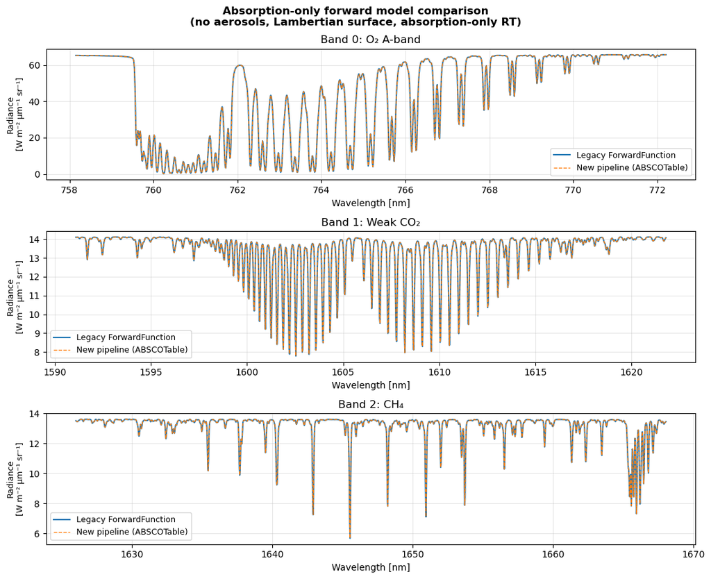

```python
fig, axes = plt.subplots(3, 1, figsize=(11, 9), sharex=False)

for i, ax in enumerate(axes):
    wl_old = s.band_wl[i]      # legacy wavelength grid [µm], blue→red
    wl_new = new_wl[i]
    R_old  = old.R_band[i]
    R_new  = new_R_band[i]

    ax.plot(wl_old * 1e3, R_old, lw=1.5, color='tab:blue',
            label='Legacy ForwardFunction', zorder=2)
    ax.plot(wl_new * 1e3, R_new, lw=1.0, color='tab:orange', ls='--',
            label='New pipeline (ABSCOTable)', zorder=3)

    ax.set_ylabel('Radiance\n[W m⁻² µm⁻¹ sr⁻¹]', fontsize=9)
    ax.set_title(f'Band {i}: {band_labels[i]}')
    ax.legend(fontsize=9)
    ax.grid(True, alpha=0.3)

axes[0].set_xlabel('Wavelength [nm]')
axes[1].set_xlabel('Wavelength [nm]')
axes[2].set_xlabel('Wavelength [nm]')

fig.suptitle('Absorption-only forward model comparison\n'
             '(no aerosols, Lambertian surface, absorption-only RT)',
             fontsize=12, fontweight='bold')
fig.tight_layout()
plt.show()
```

## 6 Residuals: old − new

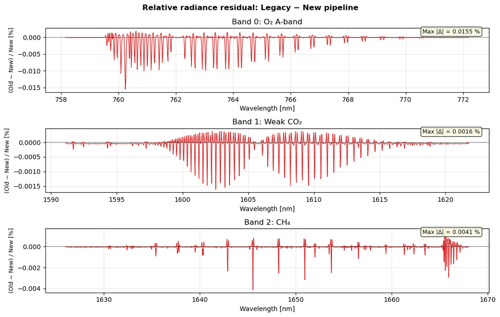

```
Peak relative differences:
  ✓  Band 0 (O₂ A-band): 0.01554 %
  ✓  Band 1 (Weak CO₂): 0.00162 %
  ✓  Band 2 (CH₄): 0.00411 %
```

```python
fig, axes = plt.subplots(3, 1, figsize=(11, 7), sharex=False)

max_rel = []
for i, ax in enumerate(axes):
    wl_old = s.band_wl[i]
    wl_new = new_wl[i]
    R_old  = old.R_band[i]
    R_new  = new_R_band[i]

    # Interpolate old onto new grid (they may have different channel counts)
    R_old_interp = np.interp(wl_new, wl_old, R_old)
    rel_diff = (R_old_interp - R_new) / R_new * 100.0   # %

    ax.plot(wl_new * 1e3, rel_diff, lw=1.0, color='tab:red')
    ax.axhline(0, color='k', lw=0.5, ls='--')
    ax.set_ylabel('(Old − New) / New [%]', fontsize=9)
    ax.set_title(f'Band {i}: {band_labels[i]}')
    ax.grid(True, alpha=0.3)

    mrd = np.max(np.abs(rel_diff))
    max_rel.append(mrd)
    ax.text(0.98, 0.92, f'Max |Δ| = {mrd:.4f} %',
            transform=ax.transAxes, ha='right', fontsize=9,
            bbox=dict(boxstyle='round', fc='lightyellow', alpha=0.8))

axes[0].set_xlabel('Wavelength [nm]')
axes[1].set_xlabel('Wavelength [nm]')
axes[2].set_xlabel('Wavelength [nm]')

fig.suptitle('Relative radiance residual: Legacy − New pipeline',
             fontsize=12, fontweight='bold')
fig.tight_layout()
plt.show()

print('\nPeak relative differences:')
for i, mrd in enumerate(max_rel):
    status = '✓' if mrd < 0.02 else '✗'
    print(f'  {status}  Band {i} ({band_labels[i]}): {mrd:.5f} %')
```

## 7 Optical depth verification

Compare the total column optical depths produced by each path.

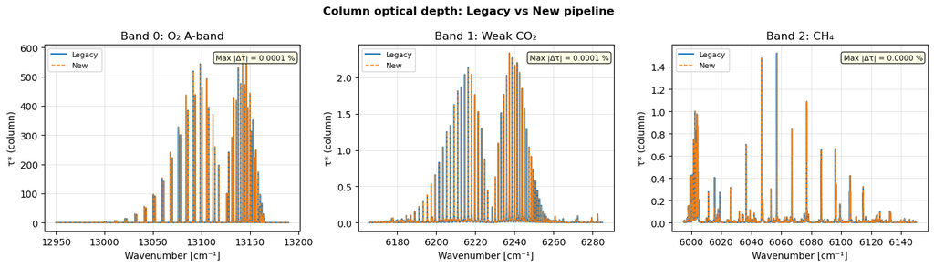

```python
fig, axes = plt.subplots(1, 3, figsize=(14, 4))

for i, ax in enumerate(axes):
    wn_hires = windows[i].wn_hires

    # ── Old tau_star from ForwardFunction ─────────────────────────────────────
    # old.tau_star_band[i] is already the total column optical depth (all molecules + Rayleigh)
    tau_old = old.tau_star_band[i]    # shape (n_hires,)

    # ── New tau_star recomputed ───────────────────────────────────────────────
    wl_mean = np.mean(windows[i].wl_instrument)
    tau_new = np.zeros(len(wn_hires))
    for mol in windows[i].molecules:
        tau_new += absco_tables[mol].tau_layer(
            atm, s.band_min_wn[i], s.band_max_wn[i]
        ).sum(axis=1)
    # Rayleigh
    n_s = 1.0 + _a_rayleigh * (1.0 + _b_rayleigh * wl_mean**2)
    sigma_r = (
        1.031e-24 * (n_s**2 - 1.0)**2
        / (wl_mean**4 * (n_s**2 + 2.0)**2)
        * (6.0 + 3.0*_rho_rayleigh) / (6.0 - 7.0*_rho_rayleigh)
    )
    tau_new += np.sum(p_diff * _Na * sigma_r / _M / _g)

    ax.plot(wn_hires, tau_old, lw=1.5, color='tab:blue', label='Legacy', zorder=2)
    ax.plot(wn_hires, tau_new, lw=1.0, color='tab:orange', ls='--',
            label='New', zorder=3)
    ax.set_xlabel('Wavenumber [cm⁻¹]')
    ax.set_ylabel('τ* (column)')
    ax.set_title(f'Band {i}: {band_labels[i]}')
    ax.legend(fontsize=8)
    ax.grid(True, alpha=0.3)

    rel = np.max(np.abs(tau_old - tau_new)) / np.mean(tau_new) * 100
    ax.text(0.98, 0.92, f'Max |Δτ| = {rel:.4f} %',
            transform=ax.transAxes, ha='right', fontsize=8,
            bbox=dict(boxstyle='round', fc='lightyellow', alpha=0.8))

fig.suptitle('Column optical depth: Legacy vs New pipeline',
             fontsize=12, fontweight='bold')
fig.tight_layout()
plt.show()
```

## 8 Column-average gas amounts

Check that `AtmosphericProfile.column_xgas()` and `ForwardFunction`'s  
`calculate_Xgas()` agree to machine precision.

```python
print('Column-average gas verification')
print('=' * 45)

xco2_old = old.xco2          # ppm
xch4_old = old.xch4          # ppb
xco2_new = atm.column_xgas('co2') * 1e6
xch4_new = atm.column_xgas('ch4') * 1e9

print(f'XCO₂  legacy = {xco2_old:.6f} ppm')
print(f'XCO₂  new    = {xco2_new:.6f} ppm')
print(f'       Δ     = {abs(xco2_old - xco2_new):.3e} ppm')
print()
print(f'XCH₄  legacy = {xch4_old:.6f} ppb')
print(f'XCH₄  new    = {xch4_new:.6f} ppb')
print(f'       Δ     = {abs(xch4_old - xch4_new):.3e} ppb')

assert abs(xco2_old - xco2_new) < 1e-6, 'XCO₂ mismatch'
assert abs(xch4_old - xch4_new) < 1e-4, 'XCH₄ mismatch'
print('\n✓  XCO₂ and XCH₄ match to floating-point precision')
```

```
Column-average gas verification
=============================================
XCO₂  legacy = 415.775253 ppm
XCO₂  new    = 415.775253 ppm
       Δ     = 5.684e-14 ppm

XCH₄  legacy = 1789.703565 ppb
XCH₄  new    = 1789.703565 ppb
       Δ     = 4.547e-13 ppb

✓  XCO₂ and XCH₄ match to floating-point precision
```

## 9 Sensitivity to atmospheric state

Run both models with a ±1 % CO₂ perturbation and compare the radiance response — the Jacobian structure should be identical.

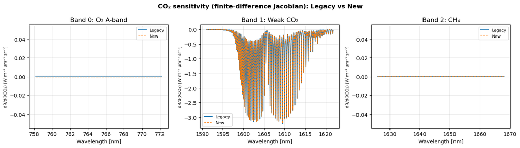

[figure not shown]

```python
# ── Perturbed CO₂ ─────────────────────────────────────────────────────────────
pct = 0.01    # 1 % perturbation
co2_plus  = s.co2_true * (1.0 + pct)
co2_minus = s.co2_true * (1.0 - pct)

# Legacy
old_plus  = ForwardFunction(absco_data=absco_data, co2=co2_plus,  tau_aerosol=None, measurement_error=False)
old_minus = ForwardFunction(absco_data=absco_data, co2=co2_minus, tau_aerosol=None, measurement_error=False)
dR_old_co2 = [(old_plus.R_band[i] - old_minus.R_band[i]) / (2*pct) for i in range(3)]

# New pipeline — helper to compute R for any CO₂ profile
def new_R_from_co2(co2_profile):
    atm_p = AtmosphericProfile(
        p_levels=s.p_true, T_levels=s.T_true, q_levels=s.q_true,
        gases={'co2': co2_profile, 'ch4': s.ch4_true},
    )
    R = []
    for i, win in enumerate(windows):
        wl_mean = np.mean(win.wl_instrument)
        F_sun = planck_new(5800.0, wl_mean * 1e-6) * _sigma_sun / 1e6
        tau = np.zeros(len(win.wn_hires))
        for mol in win.molecules:
            tau += absco_tables[mol].tau_layer(atm_p, s.band_min_wn[i], s.band_max_wn[i]).sum(axis=1)
        n_s = 1.0 + _a_rayleigh*(1.0 + _b_rayleigh*wl_mean**2)
        sr = (1.031e-24*(n_s**2-1)**2/(wl_mean**4*(n_s**2+2)**2)
              *(6+3*_rho_rayleigh)/(6-7*_rho_rayleigh))
        tau += np.sum(atm_p.p_diff * _Na * sr / _M / _g)
        I = F_sun/np.pi * s.albedo_true[i] * mu_0 * np.exp(-m * tau)
        R.append(win.convolve(I)[::-1])
    return R

R_plus_new  = new_R_from_co2(co2_plus)
R_minus_new = new_R_from_co2(co2_minus)
dR_new_co2  = [(R_plus_new[i] - R_minus_new[i]) / (2*pct) for i in range(3)]

# ── Plot sensitivity ─────────────────────────────────────────────────────────
fig, axes = plt.subplots(1, 3, figsize=(14, 4))
for i, ax in enumerate(axes):
    wl_old = s.band_wl[i]
    wl_new = new_wl[i]
    ax.plot(wl_old*1e3, dR_old_co2[i], lw=1.5, color='tab:blue', label='Legacy', zorder=2)
    ax.plot(wl_new*1e3, dR_new_co2[i], lw=1.0, color='tab:orange', ls='--', label='New', zorder=3)
    ax.set_xlabel('Wavelength [nm]')
    ax.set_ylabel('dR/d(XCO₂) [W m⁻² µm⁻¹ sr⁻¹]', fontsize=8)
    ax.set_title(f'Band {i}: {band_labels[i]}')
    ax.legend(fontsize=8)
    ax.grid(True, alpha=0.3)

fig.suptitle('CO₂ sensitivity (finite-difference Jacobian): Legacy vs New',
             fontsize=12, fontweight='bold')
fig.tight_layout()
plt.show()

fig, axes = plt.subplots(1, 3, figsize=(14, 4))
for i, ax in enumerate(axes):
    wl_old = s.band_wl[i]
    wl_new = new_wl[i]
    ax.plot(wl_old*1e3, (dR_old_co2[i]-dR_new_co2[i])/dR_old_co2[i], lw=1.5, color='tab:blue', label='Legacy', zorder=2)
    ax.set_xlabel('Wavelength [nm]')
    ax.set_ylabel('DeltadR/d(XCO₂) [%]', fontsize=8)
    ax.set_title(f'Band {i}: {band_labels[i]}')
    ax.legend(fontsize=8)
    ax.grid(True, alpha=0.3)

fig.suptitle('CO₂ sensitivity difference (finite-difference Jacobian): Legacy vs New',
             fontsize=12, fontweight='bold')
fig.tight_layout()
plt.show()
```

## 10 Summary

Run the final numerical agreement check across all three bands.

```python
print('=' * 60)
print('  SUMMARY: Legacy ForwardFunction vs New Pipeline')
print('=' * 60)

all_pass = True
for i in range(3):
    R_old  = old.R_band[i]
    R_new  = new_R_band[i]
    wl_old = s.band_wl[i]
    wl_new = new_wl[i]

    # Interpolate old onto new channel grid before comparing
    R_old_interp = np.interp(wl_new, wl_old, R_old)
    rel_max = np.max(np.abs((R_old_interp - R_new) / R_new)) * 100.0

    ok = rel_max < 0.02     # 0.02 % threshold
    all_pass = all_pass and ok
    status = '✓ PASS' if ok else '✗ FAIL'
    print(f'  {status}  Band {i} ({band_labels[i]:12s}): '
          f'max |Δ| = {rel_max:.4f} %  (threshold 0.02 %)')

print()
if all_pass:
    print('  All bands agree to < 0.02 %.  New pipeline validated. ✓')
else:
    print('  WARNING: one or more bands failed the tolerance check!')
print('=' * 60)

print()
print('New modules used:')
print('  python/atmosphere.py  →  AtmosphericProfile')
print('  python/absco.py       →  ABSCOTable (replaces sigma_lookup)')
print('  python/surface.py     →  LambertianSurface')
print('  python/instrument.py  →  SpectralWindow + ILS')
```

```
============================================================
  SUMMARY: Legacy ForwardFunction vs New Pipeline
============================================================
  ✓ PASS  Band 0 (O₂ A-band   ): max |Δ| = 0.0155 %  (threshold 0.02 %)
  ✓ PASS  Band 1 (Weak CO₂    ): max |Δ| = 0.0016 %  (threshold 0.02 %)
  ✓ PASS  Band 2 (CH₄         ): max |Δ| = 0.0041 %  (threshold 0.02 %)

  All bands agree to < 0.02 %.  New pipeline validated. ✓
============================================================

New modules used:
  python/atmosphere.py  →  AtmosphericProfile
  python/absco.py       →  ABSCOTable (replaces sigma_lookup)
  python/surface.py     →  LambertianSurface
  python/instrument.py  →  SpectralWindow + ILS
```